# Ford GoBike System Data Analysis

## by Desmond Singh

### Introduction

```
Ford GoBike is a public bicycle sharing system in the San Francisco Bay Area.
The users of this platform have access available to bikes 24/7 in San Francisco, East Bay & San Jose.
In this project, I will perform an exploratory analysis on the user utilizing this platform.
```

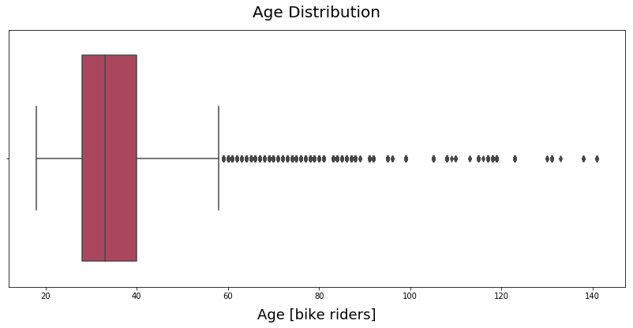

```python
plt.figure(figsize=(14,6))
sb.boxplot(x='member_age', data=df_new, palette='inferno_r', orient='h')
plt.title("Age Distribution", fontsize=20, y=1.03)
plt.xlabel("Age [bike riders]", fontsize=18, labelpad=10)
plt.savefig('image01.png');
```

#### The distribution of Riders shows Ages from 18 to 141. The Average age of Bike riders is 35.3. Since 95% of users are under the age of 57, it is better to remove anyone over the age of 65.

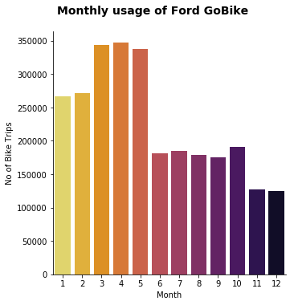

```python
# Monthly usage of Ford GoBike System
usage_map = sb.catplot(data=df_new, x='start_time_month_num', kind='count', palette='inferno_r');
usage_map.set_axis_labels("Month", "No of Bike Trips")
usage_map.fig.suptitle('Monthly usage of Ford GoBike', y=1.05, fontsize=14, fontweight='semibold');
#usage_map.set_xticklabels(rotation=30)
```

The plot shows the demand is high during The earlier part of the year, especially Mar, Apr, May. We can see that the demand goes down After may. The plot shows the demand for the system is the lowerst during Nov and Dec.

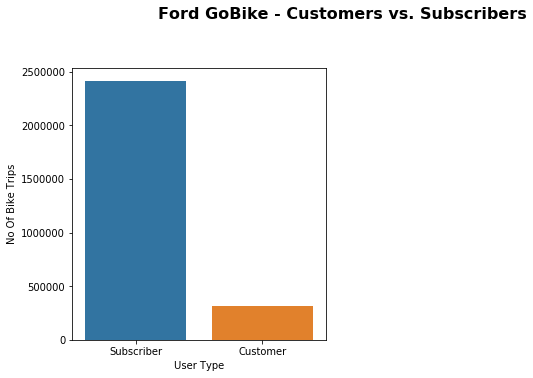

```python
# Customer vs Subscriber Bar Chart
plt.figure(figsize = [10, 5])

# code for the bar chart
plt.subplot(1, 2, 1)

usage_map = sb.countplot(data=df_new, x="user_type", order=df_new.user_type.value_counts().index)
usage_map.set_xlabel('User Type')
usage_map.set_ylabel('No Of Bike Trips')

plt.suptitle('Ford GoBike - Customers vs. Subscribers', y=1.05, fontsize=16, fontweight='semibold');
```

This Plot shows the bike sharing system is used mainly by Subscribers.

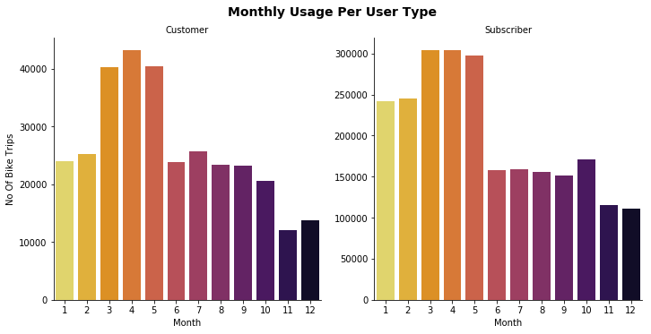

```python
# monthly Usage per user type
usage_map = sb.catplot(data=df_new, x='start_time_month_num', col="user_type", kind='count', sharey = False,
            palette='inferno_r')
usage_map.set_axis_labels("Month", "No Of Bike Trips")
usage_map.set_titles("{col_name}")
usage_map.fig.suptitle('Monthly Usage Per User Type', y=1.03, fontsize=14, fontweight='semibold');
```

For customers the bike renting is in high demand for months Mar - May. For Subscribers the high demand is in Mar- May as well but, Jan and Feb is also quite busy. After May the usage for both decreases, and it is the lowest during the winter months.

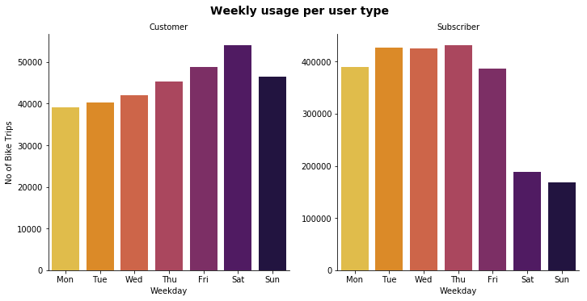

```python
# weekday usage per user type

weekday = ['Mon', 'Tue', 'Wed', 'Thu', 'Fri', 'Sat', 'Sun']
usage_map  = sb.catplot(data=df_new, x='start_time_weekday', col="user_type", kind='count', sharey = False,
            palette='inferno_r', order = weekday)
usage_map .set_axis_labels("Weekday", "No of Bike Trips")
usage_map .set_titles("{col_name}")
usage_map .fig.suptitle('Weekly usage per user type', y=1.03, fontsize=14, fontweight='semibold');
```

The plot shows us that Usage for Customers is higher Th - Sun. Whereas for subscriber usage is higher Mon - Fri.

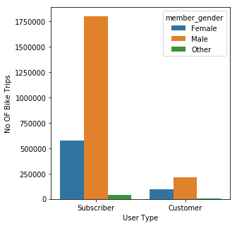

```python
plt.figure(figsize = [10, 5])

# Gender bar chart
plt.subplot(1, 2, 1)

usage_map = sb.countplot(data=df_new, x="user_type", hue="member_gender", order=df_new.user_type.value_counts().index)
usage_map.set_xlabel('User Type')
usage_map.set_ylabel('No OF Bike Trips');
```

The plot shows us that For bother Customers and Subscribers, Males utilize the service more.

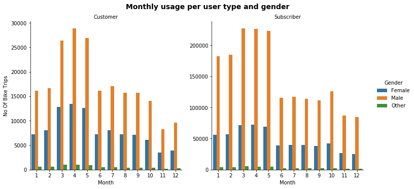

```python
# monthly usage per user type and gender

usage_map = sb.catplot(data=df_new, x='start_time_month_num', col="user_type", hue="member_gender", kind='count', sharey = False)
usage_map.set_axis_labels("Month", "No Of Bike Trips")
usage_map._legend.set_title('Gender')
usage_map.set_titles("{col_name}")
usage_map.fig.suptitle('Monthly usage per user type and gender', y=1.03, fontsize=14, fontweight='semibold');
```

For Both genders in customer plot the bike renting is in high demand for months Mar - May. For Subscribers for bother genders the high demand is in Mar- May as well but, Jan and Feb is also quite busy.

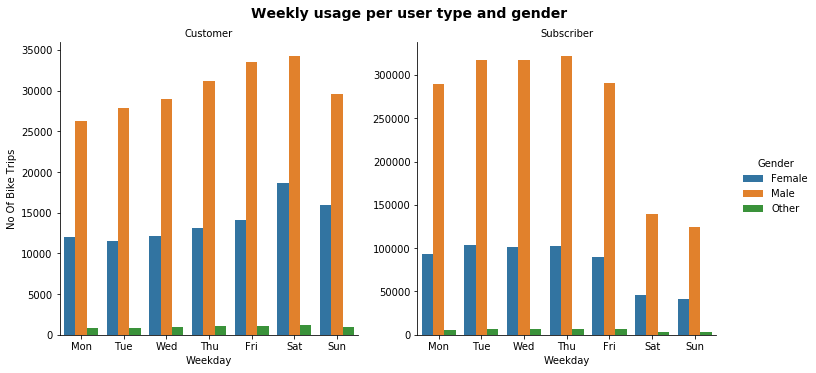

```python
# weekday usage per user type and gender

weekday = ['Mon', 'Tue', 'Wed', 'Thu', 'Fri', 'Sat', 'Sun']
usage_map = sb.catplot(data=df_new, x='start_time_weekday', col="user_type", hue='member_gender', kind='count', sharey = False,
                order = weekday)
usage_map.set_axis_labels("Weekday", "No Of Bike Trips")
usage_map._legend.set_title('Gender')
usage_map.set_titles("{col_name}")
usage_map.fig.suptitle('Weekly usage per user type and gender', y=1.03, fontsize=14, fontweight='semibold');
```

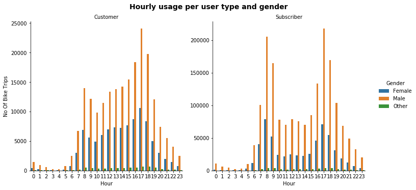

```python
# hourly usege per user type and gender

usage_map = sb.catplot(data=df_new, x='start_time_hour', col="user_type", hue='member_gender', kind='count', sharey = False)
usage_map.set_axis_labels("Hour", "No Of Bike Trips")
usage_map._legend.set_title('Gender')
usage_map.set_titles("{col_name}")
usage_map.fig.suptitle('Hourly usage per user type and gender', y=1.03, fontsize=14, fontweight='semibold');
```

During the day, both Genders utilize the system the same way: customers use bikes mainly between 8 am - 7 pm; subscribers Utilize system at around 7AM-9AM and 4PM-7PM when they go and come back from work.

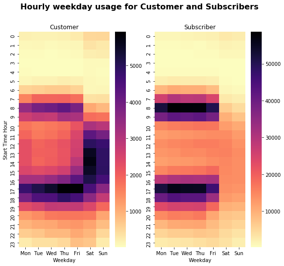

```python
# Setting the weekday order
df_new['start_time_weekday'] = pd.Categorical(df_new['start_time_weekday'],
                                                categories=['Mon','Tue','Wed','Thu','Fri','Sat', 'Sun'],
                                                ordered=True)
plt.figure(figsize=(9,8))
plt.suptitle('Hourly weekday usage for Customer and Subscribers', fontsize=16, fontweight='bold')

# heatmap for customers
plt.subplot(1, 2, 1)
df_cust = df_new.query('user_type == "Customer"').groupby(["start_time_hour", "start_time_weekday"])["bike_id"].size().reset_index()
df_cust = df_cust.pivot("start_time_hour", "start_time_weekday", "bike_id")
sb.heatmap(df_cust, cmap="magma_r")

plt.title("Customer", y=1.015)
plt.xlabel('Weekday')
plt.ylabel('Start Time Hour')

# heatmap for subscribers
plt.subplot(1, 2, 2)
df_sub = df_new.query('user_type == "Subscriber"').groupby(["start_time_hour", "start_time_weekday"])["bike_id"].size().reset_index()
df_sub = df_sub.pivot("start_time_hour", "start_time_weekday", "bike_id")
sb.heatmap(df_sub, cmap="magma_r")

plt.title("Subscriber", y=1.015)
plt.xlabel('Weekday')
plt.ylabel('');
```

Customer Plot: During weekdays: Service usage is higher during 8AM - 9AM and 4PM-6PM. During weekend: Service usage is high between 10AM - 6PM.

Subscriber Plot: During weekday: Service usage is high during 7AM - 9AM and 4PM - 7PM Durin weekend: Service is usage is low on weekends, No significant effect of day time noticed on weekends.